# Introduction

Optimization project

Dataset: Diamond Dataset link (https://www.kaggle.com/shivam2503/diamonds)

This project aims to predict the price of diamond in Diamond data set. This is a regression problem.

This classic dataset contains the prices and other attributes of almost 54,000 diamonds.

Features

- price price in US dollars (\$326--\$18,823)
- carat weight of the diamond (0.2--5.01)
- cut quality of the cut (Fair, Good, Very Good, Premium, Ideal)
- color diamond colour, from J (worst) to D (best)
- clarity a measurement of how clear the diamond is (I1 (worst), SI2, SI1, VS2, VS1, VVS2, VVS1, IF (best))
- x length in mm (0--10.74)
- y width in mm (0--58.9)
- z depth in mm (0--31.8)
- depth total depth percentage = z / mean(x, y) = 2 * z / (x + y) (43--79)
- table width of top of diamond relative to widest point (43--95)

```python
#import lib and download dataset

from sklearn.datasets import fetch_california_housing
from sklearn.metrics import mean_squared_error
import seaborn as sns
import pandas as pd
# To plot pretty figures
%matplotlib inline
import matplotlib as mpl
import matplotlib.pyplot as plt
import seaborn as sns
from scipy.linalg import svdvals # Singular values
mpl.rc('axes', labelsize=14)
mpl.rc('xtick', labelsize=12)
mpl.rc('ytick', labelsize=12)

# Ignore useless warnings (see SciPy issue #5998)
import warnings
warnings.filterwarnings(action="ignore", message="^internal gelsd")
!wget https://github.com/batuan/data/raw/main/diamonds.csv
```

[output not shown]

# 1 Presentation the dataset

```python
data = pd.read_csv('diamonds.csv')
data.drop(columns=data.columns[0], axis=1, inplace=True) # drop index collumn
#drop the useless data (that mean x, y, z = 0)
data = data.drop(data[data["x"]==0].index)
data = data.drop(data[data["y"]==0].index)
data = data.drop(data[data["z"]==0].index)
```

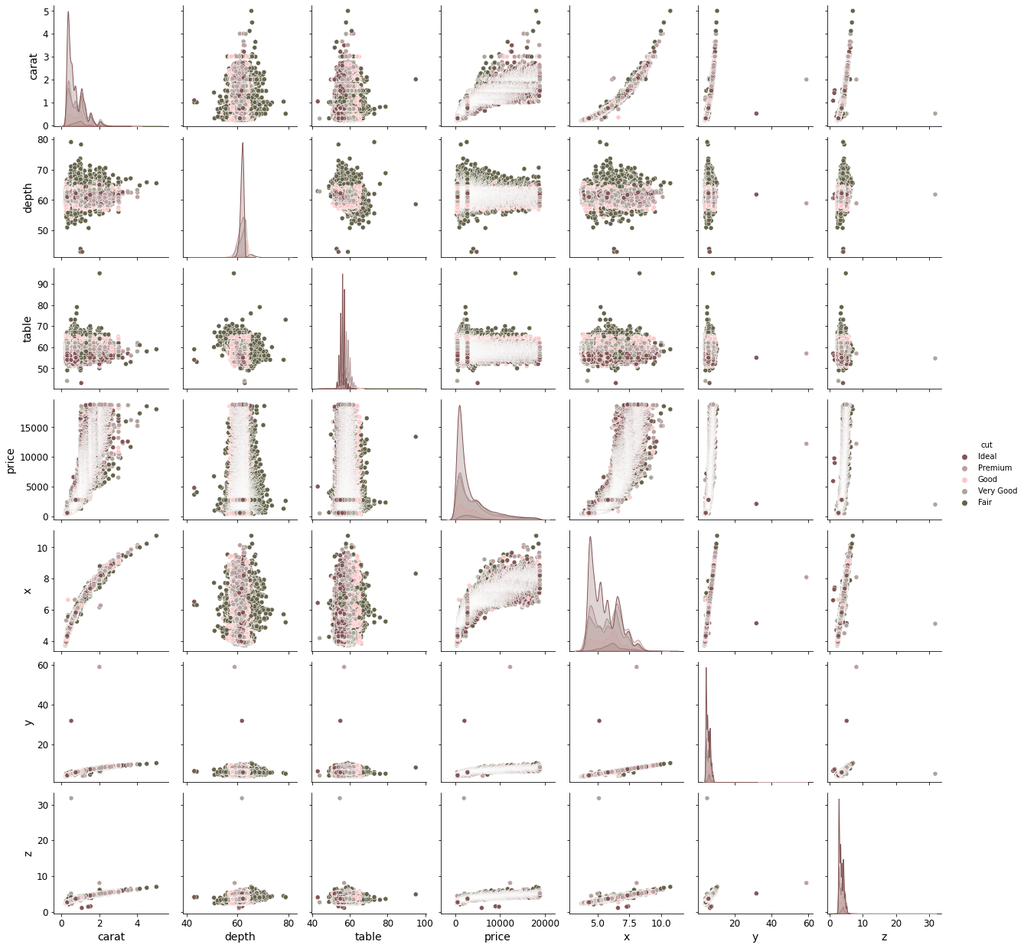

```python
#Let's have a look at data
shade = ["#835656", "#baa0a0", "#ffc7c8", "#a9a799", "#65634a"]#shades for hue
ax = sns.pairplot(data, hue= "cut",palette=shade)# I chose "cut" as hue. We can also examine other attributes in hue with less value count.
```

```python
#Dropping the outliers. There are some outier, that make the model is not good to predict.
data = data[(data["depth"]<75)&(data["depth"]>45)]
data = data[(data["table"]<80)&(data["table"]>40)]
data = data[(data["x"]<30)]
data = data[(data["y"]<30)]
data = data[(data["z"]<30)&(data["z"]>2)]

# Make copy to avoid changing original data
label_data = data.copy()
from sklearn.preprocessing import OneHotEncoder, LabelEncoder
# Apply label encoder to each column with categorical data
label_encoder = LabelEncoder()
s = (data.dtypes =="object")
object_cols = list(s[s].index)
for col in object_cols:
    label_data[col] = label_encoder.fit_transform(label_data[col])
```

[output not shown]

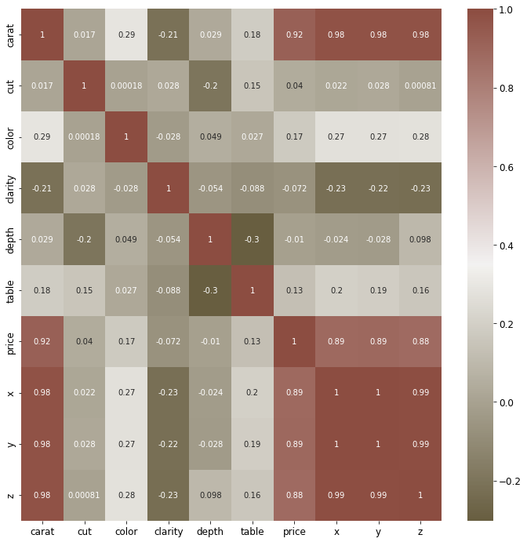

```python
#correlation matrix
cmap = sns.diverging_palette(70,20,s=50, l=40, n=6,as_cmap=True)
corrmat= label_data.corr()
f, ax = plt.subplots(figsize=(12,12))
sns.heatmap(corrmat,cmap=cmap,annot=True, )
plt.plot()
```

```python
data.info()
```

```
<class 'pandas.core.frame.DataFrame'>
Int64Index: 53907 entries, 0 to 53939
Data columns (total 10 columns):
 #   Column   Non-Null Count  Dtype
---  ------   --------------  -----
 0   carat    53907 non-null  float64
 1   cut      53907 non-null  object
 2   color    53907 non-null  object
 3   clarity  53907 non-null  object
 4   depth    53907 non-null  float64
 5   table    53907 non-null  float64
 6   price    53907 non-null  int64
 7   x        53907 non-null  float64
 8   y        53907 non-null  float64
 9   z        53907 non-null  float64
dtypes: float64(6), int64(1), object(3)
memory usage: 4.5+ MB
```

```python
data.describe().T
```

|  | count | mean | std | min | 25% | 50% | 75% | max |
| --- | --- | --- | --- | --- | --- | --- | --- | --- |
| carat | 53907.0 | 0.797628 | 0.473765 | 0.20 | 0.40 | 0.70 | 1.04 | 5.01 |
| depth | 53907.0 | 61.749741 | 1.420119 | 50.80 | 61.00 | 61.80 | 62.50 | 73.60 |
| table | 53907.0 | 57.455948 | 2.226153 | 43.00 | 56.00 | 57.00 | 59.00 | 79.00 |
| price | 53907.0 | 3930.584470 | 3987.202815 | 326.00 | 949.00 | 2401.00 | 5322.00 | 18823.00 |
| x | 53907.0 | 5.731463 | 1.119384 | 3.73 | 4.71 | 5.70 | 6.54 | 10.74 |
| y | 53907.0 | 5.733292 | 1.111252 | 3.68 | 4.72 | 5.71 | 6.54 | 10.54 |
| z | 53907.0 | 3.539441 | 0.691434 | 2.06 | 2.91 | 3.53 | 4.04 | 6.98 |

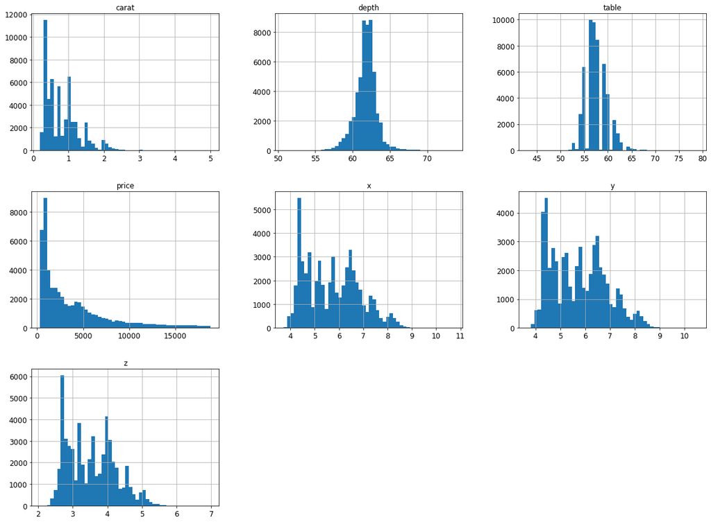

```python
data.hist(bins=50, figsize=(20,15))
plt.show();
```

# 2 Mandatory things

- Test of batch gradient descent, with exploration of at least the descent step size and link with the course.
- Test of accelerated gradient descent (Nesterov),
- Test of stochastic gradient descent (impact of hyperparameters such as learning rate, (mini)-batch size, diagonal scaling, etc)
- Test of regularization (ridge/lasso using iterative soft thresholding)

```python
import numpy as np
from sklearn.model_selection import train_test_split
from sklearn.preprocessing import MinMaxScaler, StandardScaler


X = label_data.drop(["price"],axis =1)
y = label_data["price"]
scaler_x = StandardScaler()
scaler_y = StandardScaler()
X = scaler_x.fit_transform(X)
y = scaler_y.fit_transform(y.to_numpy().reshape(-1, 1))
X_train, X_test, y_train, y_test = train_test_split(X, y,test_size=0.25, random_state=42)
class_names = list(label_data.drop(["price"],axis =1).columns.values)
```

```python
# U, s, V = np.linalg.svd(X_train)
# plt.plot(s, '.-');
class_names
```

```
['carat', 'cut', 'color', 'clarity', 'depth', 'table', 'x', 'y', 'z']
```

## 2.1 Batch gradient descent

## Linear Regression

We look for a linear relationship $ y_i \approx <x,a_i> $ written in matrix format $ y= A x $ where the rows of $A \in \mathbb R^{n \times p}$ stores the features $a_i \in \mathbb R^p$.

Since here $n > p$, this is an over-determined system, which can solved in the least square sense

$$ \mbox{minimize}_{\mathbf{w} \in \mathbb{R}^d} f(\mathbf{w}):=\tfrac{1}{2} \lVert \mathbf{A}\mathbf{w}- \mathbf{y} \rVert^{2} $$

The gradient of $f$ is $$ \nabla f(w) = A^\top (\mathbf{A}\mathbf{w}- \mathbf{y} ). $$

and The maxium step size allowable by the gradient descent is

Sum informations from course:

1. $\nabla f$ is $\left(\frac{\|\mathbf{X}^T \mathbf{X}\|}{n}+\lambda\right)$-Lipschitz continuous.

$$ \tau \leq \tau_\max = \frac{2}{||{AA^\top}||_{op}} $$

where $||{\cdot}||_{op}$ is the maximum singular eigenvalue.

We also calculate the solution by using Moore-Penrose pseudo-inverse

$$ w = (X^\top X)^{-1} X^\top y $$

```python
#calculate the solution
n, d = X_train.shape
w_target = np.linalg.solve( X_train.transpose().dot(X_train), X_train.transpose().dot(y_train) )
print("loss on solution is: ")
print(np.linalg.norm(X_train.dot(w_target)-y_train)**2/(2))
print("loss on testing set is:")
print(mean_squared_error(y_test, X_test.dot(w_target)))
```

```
loss on solution is:
2304.5874945085493
loss on testing set is:
0.11011693465089858
```

```python
#1 batch gradient descent
def f(X, y, w): return 0.5*np.linalg.norm(X.dot(w) - y)**2
def Gradf(X, y, w): return X.transpose().dot(X.dot(w)-y)
tau = 2/np.linalg.norm(X_train,2)**2

def gd(w0, X, y, step, n_iter=100, verbose=False, lamda=0.0001):
    """
        A code for gradient descent on quadratic functions.

        Inputs:
            w0: Initial vector
            X: input matrix
            y: price
            step: Value of the stepsize
            n_iter: Number of iterations
            verbose: Boolean value indicating whether the outcome of every iteration should be displayed

        Outputs:
            w_output: Final iterate of the method
            objvals: History of function values (output as a Numpy array of length n_iter+1)

    """
    ############
    # Initial step: Compute and plot some initial quantities

    # objective history
    objvals = []

    # Initial value of current iterate
    w = w0.copy()
    # Initialize iteration counter
    k=0
    # Current objective
    obj = f(X, y, w)
    objvals.append(obj);
    # Plot the initial values if asked to
    if verbose:
        print("Gradient Descent:")
        print(' | '.join([name.center(8) for name in ["iter", "fval"]]))
        print(' | '.join([("%d" % k).rjust(8),("%.2e" % obj).rjust(8)]))
    ####################
    # Main loop
    while (k < n_iter):
        # Compute the gradient
        g = Gradf(X, y, w)
        w[:] = w - step * g
        obj = f(X, y, w)
        objvals.append(obj)
        # Plot relevant information if asked to
        if verbose:
            print(' | '.join([("%d" % k).rjust(8),("%.2e" % obj).rjust(8)]))
        # Increment the iteration count
        k += 1
    # End main loop
    ######################

    # Output
    w_output = w.copy()
    return w_output, np.array(objvals)
```

```python
C = X_train.transpose().dot(X_train)

L = np.linalg.norm(C, ord=2) #condition convergence
mu = np.linalg.norm(C,-2)
tau_opt = 2 / ( L + mu )
print('L={}, mu={}, 1/tau_opt={}'.format(L, mu, 1/tau_opt))
```

```
L=169707.0156081245, mu=27.726218599668417, 1/tau_opt=84867.37091336209
```

```python
#testing
# Implementation - Running GD with 10 random initial points
nruns=10
nits=200

u = np.array(range(nits))

avg_1 = 0
avg_2 = 0

for i in range(nruns):
    w0 = np.random.randn(d, 1)
    wgd1, obj_gd1 = gd(w0, X_train, y_train,1/L, nits)
    avg_1 += obj_gd1[-1]

    w0 = np.random.randn(d, 1)
    wgd2, obj_gd2 = gd(w0, X_train, y_train, 1.95/(L+mu), nits)
    avg_2 += obj_gd2[-1]

print('Average function value with 1/L:',avg_1/nruns)
print('Average function value with 2/(L):',avg_2/nruns)
```

```
Average function value with 1/L: 2499.055484692552
Average function value with 2/(L): 2378.056209846823
```

```python
print("MSE on testing set with GD Method = {}".format(mean_squared_error(y_test, X_test.dot(wgd1))))
```

```
MSE on testing set with GD Method = 0.11595182705113011
```

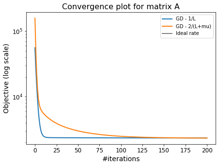

```python
# Implementation - Compare both variants on 1 run
from math import log
plt.figure(figsize=(7, 5))
plt.semilogy(obj_gd1, label="GD - 1/L", lw=2)
plt.semilogy(obj_gd2, label="GD - 2/(L+mu)", lw=2)
plt.semilogy(log(1-mu/L)*u, label='Ideal rate',color='gray',lw=2)
plt.title("Convergence plot for matrix A", fontsize=16)
plt.xlabel("#iterations", fontsize=14)
plt.ylabel("Objective (log scale)", fontsize=14)
plt.legend()
plt.show()
```

```python
#compare on n run
```

## 2.2 Batch gradient descent with acceleration - Nesterov

Unlike gradient, Nesterov method update $w_{k+1}$ by combine $w_{k}$ and $w_{k-1}$. This method can be written as the iteration below:

$$ \left\{\begin{array}{l} \boldsymbol{w}_{k+1}=\boldsymbol{z}_{k}-\alpha_{k} \nabla f\left(\boldsymbol{z}_{k}\right) \\ \boldsymbol{z}_{k+1}=\boldsymbol{w}_{k+1}+\beta_{k+1}\left(\boldsymbol{w}_{k+1}-\boldsymbol{w}_{k}\right) \end{array}\right. $$

where $\alpha_{k}$ is step size parrameters and $\beta_{k}$ is calculated by:

$$ t_{k+1}=\frac{1}{2}\left(1+\sqrt{1+4 t_{k}^{2}}\right), t_{0}=0, \quad \beta_{k}=\frac{t_{k}-1}{t_{k+1}} $$

```python
#1 batch gradient descent with nesterov
def gd_nesterov(w0, X, y, step, n_iter=100, momentum=None,verbose=False, lamda=0.0001, method='nesterov'):
    ############
    # Initial step: Compute and plot some initial quantities
    # objective history
    objvals = []

    # Initial value of current iterate
    w = w0.copy()
    w_new = w0.copy()
    z = w0.copy()

    if method =='nesterov':
      tk = 0.0
      tkp1 = 0.0
      momentum = 0.0

    # Initialize iteration counter
    k=0

    # Current objective
    obj = f(X, y, w)
    objvals.append(obj);

    # Plot the initial values if asked to
    if verbose:
        print("Gradient Descent:")
        print(' | '.join([name.center(8) for name in ["iter", "fval"]]))
        print(' | '.join([("%d" % k).rjust(8),("%.2e" % obj).rjust(8)]))

    ####################
    # Main loop
    while (k < n_iter):

        # Compute the gradient
        g = Gradf(X, y, w) #X.T.dot(X.dot(w)-y)

        # Select the stepsize and perform the update
        w_new = z - step * g
        # print(momentum)
        z = w_new + momentum*(w_new - w)
        w = w_new

        #update momemtum
        if method == 'nesterov':

          tkp1 = 0.5*(1+np.sqrt(1+4*tk*tk))
          momentum = (tk-1)/(tkp1+1)
          # print('update {} {} {}'.format(tkp1, momentum, tk))
          tk = tkp1


        # Compute the new objective value
        obj = f(X, y, z)#(np.linalg.norm(X.dot(w)-y)**2)*0.5
        objvals.append(obj)

        # Plot relevant information if asked to
        if verbose:
            print(' | '.join([("%d" % k).rjust(8),("%.2e" % obj).rjust(8)]))

        # Increment the iteration count
        k += 1

    # End main loop
    ######################

    # Output
    w_output = w.copy()
    return w_output, np.array(objvals)
```

*Implementation: Consider the following methods applied to the minimization of $q$:*

- *Gradient descent with stepsize $\tfrac{1}{L}$.*
- *Nesterov's method with stepsize $\tfrac{1}{L}$ and variable momentum parameter.*
- *Nesterov's method with stepsize $\tfrac{1}{L}$ and momentum parameter $\tfrac{\sqrt{L}-\sqrt{\mu}}{\sqrt{L}+\sqrt{\mu}}$.*

*Compare the results obtained after running the methods on 10 different initial points. Plot a representative run.*

```python
#testing compare nestes
# Implementation - Running all methods with 10 random initial points
nruns=10
nits=400

beta = (np.sqrt(L)-np.sqrt(mu))/(np.sqrt(L)+np.sqrt(mu))

avg_gd = 0
avg_hb = 0
avg_n = 0
avg_ns = 0

for i in range(nruns):
    w0 = np.random.randn(d, 1)
    w_gd, obj_gd = gd(w0,X_train,y_train,1/L,nits)
    avg_gd += obj_gd[-1]

    w0 = np.random.randn(d, 1)
    w_n, obj_n = gd_nesterov(w0,X_train,y_train,1/L,nits, method='nesterov')
    avg_n += obj_n[-1]

    w0 = np.random.randn(d, 1)
    w_ns, obj_ns = gd_nesterov(w0,X_train, y_train,1/L,nits,momentum=beta,method='strongconvex')
    avg_ns += obj_ns[-1]

print('Average function value for GD:',avg_gd/nruns)
print('Average function value for Nesterov (convex version)',avg_n/nruns)
print('Average function value for Nesterov (strongly convex version)',avg_ns/nruns)
```

```
Average function value for GD: 2372.4565316524604
Average function value for Nesterov (convex version) 2304.8287376110757
Average function value for Nesterov (strongly convex version) 2309.712042343417
```

```python
print("MSE on testing set with GD Nesterov Method = {}".format(mean_squared_error(y_test, X_test.dot(w_ns))))
```

```
MSE on testing set with GD Nesterov Method = 0.11039411087441896
```

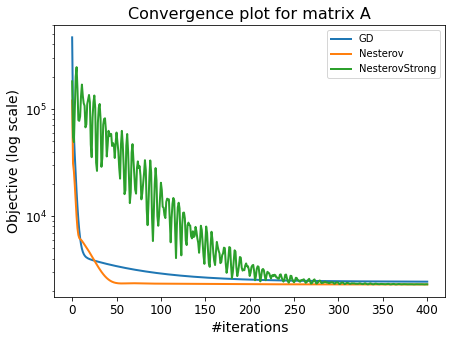

```python
# Implementation - Compare both variants on 1 run
plt.figure(figsize=(7, 5))
plt.semilogy(obj_gd, label="GD", lw=2)
plt.semilogy(obj_n, label="Nesterov", lw=2)
plt.semilogy(obj_ns, label="NesterovStrong", lw=2)
plt.title("Convergence plot for matrix A", fontsize=16)
plt.xlabel("#iterations", fontsize=14)
plt.ylabel("Objective (log scale)", fontsize=14)
plt.legend()
plt.show()
```

After 400 epochs, Nesterov and Nesterov Strong is convegence better than Gradient Descent

## 2.3 Mini batch and stochastic gradient

Stohastic gradient descent fiding a solution for a finite sum function $f(\mathbf{w})=\tfrac{1}{n}\sum_{i=1}^n f_i(\mathbf{w})$, and for linear regression problem, the function is rewrite as:

$$ \mathrm{minimize}_{\mathbf{w} \in \mathbb{R}^d} f(\mathbf{w}) := \frac{1}{2 n} \|\mathbf{X} \mathbf{w} - \mathbf{y}\|^2 = \frac{1}{n} \left(\frac{1}{2}\sum_{i=1}^n (\mathbf{x}_i^T \mathbf{w} - y_i)^2 \right). $$

The algorithm will update $w$: $$ w_{k+1} = w_k - \tau_k \nabla f_{i_k}(w_k)$$ where at each iteration $i_k$ is drawn in $\{1,\ldots,n\}$ uniformly at random.

A more general version of stochastic gradient, called batch stochastic gradient, is given by the iteration $$ \mathbf{w}_{k+1} = \mathbf{w}_k - \frac{\alpha_k}{|S_k|} \sum_{i \in S_k} \nabla f_i(\mathbf{w}_k) $$

```python
# Stochastic gradient implementation
def stoch_grad(w0,problem,wtarget,stepchoice=0,step0=1, n_iter=1000,nb=1,with_replace=False,verbose=True):
    """
        A code for gradient descent with various step choices.

        Inputs:
            w0: Initial vector
            problem: Problem structure
                problem.fun() returns the objective function, which is assumed to be a finite sum of functions
                problem.n returns the number of components in the finite sum
                problem.grad_i() returns the gradient of a single component f_i
                problem.lipgrad() returns the Lipschitz constant for the gradient
                problem.cvxval() returns the strong convexity constant
                problem.lambda returns the value of the regularization parameter
            wtarget: Target minimum (unknown in practice!)
            stepchoice: Strategy for computing the stepsize
                0: Constant step size equal to 1/L
                t>0: Step size decreasing in 1/(k+1)**t
            step0: Initial steplength (only used when stepchoice is not 0)
            n_iter: Number of iterations, used as stopping criterion
            nb: Number of components drawn per iteration/Batch size
                1: Classical stochastic gradient algorithm (default value)
            with_replace: Boolean indicating whether components are drawn with or without replacement
                True: Components drawn with replacement
                False: Components drawn without replacement (Default)
            verbose: Boolean indicating whether information should be plot at every iteration (Default: False)

        Outputs:
            w_output: Final iterate of the method (or average if average=1)
            objvals: History of function values (Numpy array of length n_iter at most)
            normits: History of distances between iterates and optimum (Numpy array of length n_iter at most)
    """
    ############
    # Initial step: Compute and plot some initial quantities

    # objective history
    objvals = []

    # iterates distance to the minimum history
    normits = []

    # Lipschitz constant
    L = problem.lipgrad()
    # Number of samples
    n = problem.n
    # Initial value of current iterate
    w = w0.copy()
    nw = np.linalg.norm(w)
    # Initialize iteration counter
    k=0
    # Current objective
    obj = problem.fun(w)
    objvals.append(obj);
    # Current distance to the optimum
    nmin = np.linalg.norm(w-wtarget)
    normits.append(nmin)

    if verbose:
        # Plot initial quantities of interest
        print("Stochastic Gradient, batch size=",nb,"/",n)
        print(' | '.join([name.center(8) for name in ["iter", "fval", "normit"]]))
        print(' | '.join([("%d" % k).rjust(8),("%.2e" % obj).rjust(8),("%.2e" % nmin).rjust(8)]))

    ################
    # Main loop
    while (k < n_iter and nw < 10**100):
        # Draw the batch indices
        ik = np.random.choice(n,nb,replace=with_replace)# Batch gradient
        # Stochastic gradient calculation
        sg = np.zeros((d,1))
        for j in range(nb):
            gi = problem.grad_i(ik[j],w).reshape(-1,1)
            sg = sg + gi
        sg = (1/nb)*sg

        if stepchoice==0:
            w[:] = w - (step0/L) * sg
        elif stepchoice>0:
            sk = float(step0/((k+1)**stepchoice))
            w[:] = w - sk * sg

        nw = np.linalg.norm(w) #Computing the norm to measure divergence

        obj = problem.fun(w)
        nmin = np.linalg.norm(w-wtarget)

        k += 1
        # Plot quantities of interest at the end of every epoch only
        if (k*nb) % n == 0:
            objvals.append(obj)
            normits.append(nmin)
            if verbose:
                print(' | '.join([("%d" % k).rjust(8),("%.2e" % obj).rjust(8),("%.2e" % nmin).rjust(8)]))

    # End of main loop
    #################

    # Plot quantities of interest for the last iterate (if needed)
    if (k*nb) % n > 0:
        objvals.append(obj)
        normits.append(nmin)
        if verbose:
            print(' | '.join([("%d" % k).rjust(8),("%.2e" % obj).rjust(8),("%.2e" % nmin).rjust(8)]))

    # Outputs
    w_output = w.copy()

    return w_output, np.array(objvals), np.array(normits)
```

```python
#testing
# Python class for regression problems
class RegPb(object):
    '''
        A class for regression problems with linear models.
        Attributes:
            X: Data matrix (features)
            y: Data vector (labels)
            n,d: Dimensions of X
            loss: Loss function to be considered in the regression
                'l2': Least-squares loss
                'logit': Logistic loss
            lbda: Regularization parameter
    '''
    # Instantiate the class
    def __init__(self, X, y,lbda=0,loss='l2'):
        self.X = X
        self.y = y
        self.n, self.d = X.shape
        self.loss = loss
        self.lbda = lbda


    # Objective value
    def fun(self, w):
      return np.linalg.norm(self.X.dot(w) - self.y) ** 2 / (2. * self.n) + self.lbda * np.linalg.norm(w) ** 2 / 2.

    # Partial objective value
    def f_i(self, i, w):
      return np.linalg.norm(self.X[i].dot(w) - self.y[i]) ** 2 / (2.) + self.lbda * np.linalg.norm(w) ** 2 / 2.

    # Full gradient computation
    def grad(self, w):
      w = w.reshape(-1,1)
      return self.X.T.dot(self.X.dot(w) - self.y) / self.n + self.lbda * w.reshape(-1,1)

    # Partial gradient
    def grad_i(self,i,w):
        x_i = self.X[i]

        return (x_i.dot(w) - self.y[i]) * x_i.reshape(-1,1) + self.lbda*w.reshape(-1,1)

    # Lipschitz constant for the gradient
    def lipgrad(self):
      L = np.linalg.norm(self.X.T.dot(self.X), ord=2) / self.n + self.lbda
      return L
    # ''Strong'' convexity constant (could be zero if self.lbda=0)
    def cvxval(self):
      s = svdvals(self.X)
      mu = min(s)**2 / self.n
      return mu + self.lbda
pblinreg = RegPb(X_train, y_train, lbda=0,loss='l2')
```

```python
#1 run with constant step size: 1/L
nb_epochs = 60
n = pblinreg.n
nbset = 1
w0 = np.zeros((d,1))
w_a, obj_a, nits_a = stoch_grad(w0,pblinreg,w_target,stepchoice=0,step0=1, n_iter=nb_epochs,nb=n)

#2 run with constant step size with difference number iter
# Run b - Stochastic gradient with constant stepsize
# The version below may diverges, in which case the bound on norm(w) in the code will be triggered
# w_b, obj_b, nits_b = stoch_grad(w0,pblinreg,w_target,stepchoice=0,step0=1, n_iter=int(nb_epochs*n/nbset),nb=1)

#3 run with decrease step size
# # Run Gradient descent with decreasing stepsize
w_c, obj_c, nits_c = stoch_grad(w0,pblinreg,w_target,stepchoice=0.5,step0=0.2, n_iter=nb_epochs,nb=n)
# # Run Stochastic gradient with decreasing stepsize
w_d, obj_d, nits_d = stoch_grad(w0,pblinreg,w_target,stepchoice=0.5,step0=0.2, n_iter=nb_epochs*n,nb=1)
```

```
Stochastic Gradient, batch size= 40430 / 40430
  iter   |   fval   |  normit
       0 | 5.08e-01 | 1.88e+00
       1 | 1.15e-01 | 1.82e+00
       2 | 1.01e-01 | 1.81e+00
       3 | 9.64e-02 | 1.81e+00
       4 | 9.35e-02 | 1.80e+00
       5 | 9.14e-02 | 1.80e+00
       6 | 8.98e-02 | 1.80e+00
       7 | 8.86e-02 | 1.79e+00
       8 | 8.75e-02 | 1.79e+00
       9 | 8.66e-02 | 1.79e+00
      10 | 8.59e-02 | 1.79e+00
      11 | 8.52e-02 | 1.79e+00
      12 | 8.47e-02 | 1.78e+00
```

[output cut: 48 more lines]

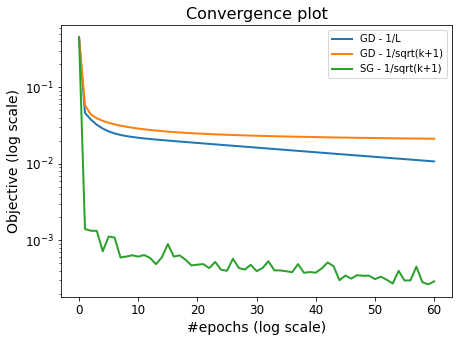

```python
# Plot the comparison of variants of GD/SG with the same stepsize rule
# NB: The x-axis is in epochs (1 iteration of GD).
f_min_log = pblinreg.fun(w_target)
# In terms of objective value (logarithmic scale)
plt.figure(figsize=(7, 5))
plt.semilogy(obj_a-f_min_log, label="GD - 1/L", lw=2)
# plt.semilogy(obj_b-f_min_log, label="SG - 1/L", lw=2)
plt.semilogy(obj_c-f_min_log, label="GD - 1/sqrt(k+1)", lw=2)
plt.semilogy(obj_d-f_min_log, label="SG - 1/sqrt(k+1)", lw=2)
plt.title("Convergence plot", fontsize=16)
plt.xlabel("#epochs (log scale)", fontsize=14)
plt.ylabel("Objective (log scale)", fontsize=14)
plt.legend()
plt.show()
```

```python
print("MSE on testing set with SG Method = {}".format(mean_squared_error(y_test, X_test.dot(w_d))))
```

```
MSE on testing set with SG Method = 0.11088003374521914
```

## 2.4 Test of regularization

Regularization is obtained by introducing a penalty. It is often called ridge regression, and is defined as

$$ min_{ w } \|{Aw-y}^2\| + \lambda \|{w}\|^2 $$ where $\lambda>0$ is the regularization parameter.

Lasso regresson change the norm-2 to norm-1

$$ min_{ w } \|{Aw-y}^2\| + \lambda \|{w}\|_{1} $$

where $\|{w}\|_{1} = ∑_{i}|w_{i}|$

The simplest iterative algorithm to perform the minimization is the so-called iterative soft thresholding (ISTA), aka proximal gradient aka forward-backward.

```
fmin = 2442.8881384859856
```

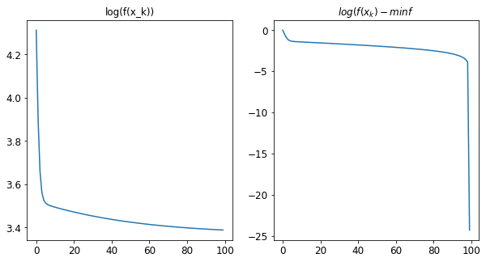

```python
# code for lasso
def f(w,Lambda): return 1/(2)*np.linalg.norm(X_train.dot(w)-y_train)**2 + Lambda*np.linalg.norm(w,1)
def Soft(w,s): return np.maximum( abs(w)-s, np.zeros(w.shape)) * np.sign(w)

tau = 1.5/np.linalg.norm(X_train,2)**2
lmax = abs( X_train.transpose().dot(y_train)).max()
Lambda = 0.01

C = X_train.transpose().dot(X_train)
u = X_train.transpose().dot(y_train)
def ISTA(w,Lambda,tau): return Soft( w-tau*( C.dot(w)-u ), Lambda*tau )

niter = 100
flist = np.zeros((niter,1))
x = np.zeros((d,1))
for i in np.arange(0,niter):
    flist[i] = f(x,Lambda)
    x = ISTA(x,Lambda,tau)
ndisp = int(niter)

print("fmin = {}".format(f(x, Lambda)))

fig = plt.figure(figsize=(10,5))
ax = fig.add_subplot(121)
ax2 = fig.add_subplot(122)
# ax.plot(x, np.sin(x))
# ax2.plot(x, np.cos(x), 'r:')

# plt.clf
# plt.subplot(1,2,1)
ax.plot(np.log10(flist[0:ndisp]))
ax.axis('tight')
ax.set_title('log(f(x_k))')

# plt.subplot(1,2,2)
e = np.log10( flist[0:ndisp]-flist.min() +1e-20)
ax2.plot(e-e[0])
ax2.axis('tight')
ax2.set_title('$log(f(x_k)-min f$')
```

```
Lasso: 33.64505976267425%
```

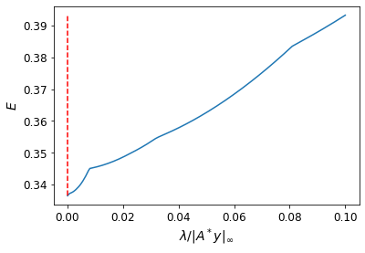

```python
q = 200
lambda_list = lmax*np.linspace(.1,1e-4,q)
X = np.zeros( (d,q) )
E = np.zeros( (q,1) )
x = np.zeros((d,1))
niter = 500
for iq in np.arange(0,q):
    Lambda = lambda_list[iq]
    # ISTA #
    for i in np.arange(0,niter):
        x = ISTA(x,Lambda,tau)
    X[:,iq] = x.flatten() # bookkeeping
    E[iq] = np.linalg.norm(X_train.dot(x)-y_train) / np.linalg.norm(y_train)
# find optimal Lambda
i = E.argmin()
lambda0 = lambda_list[i]
xSparse = X[:,i]
print( 'Lasso: ' + str(E.min()*100) + '%' )
# Display error evolution.
plt.clf
plt.plot(lambda_list/lmax, E)
plt.plot( [lambda0/lmax,lambda0/lmax], [E.min(),E.max()], 'r--')
plt.axis('tight')
plt.xlabel('$\lambda/|A^* y|_\infty$')
plt.ylabel('$E$')
```

[figure not shown]

```python
plt.clf
for i in np.arange(0,d):
    plt.plot(lambda_list/lmax, X[i,:], label=class_names[i])
plt.plot( [lambda0/lmax,lambda0/lmax], [X.flatten().min(),X.flatten().max()], 'r--')
plt.axis('tight')
plt.xlabel('$\lambda/|A^* y|_\infty$')
plt.ylabel('$x_i$')
plt.legend()
```

```
Ridge: 33.5115965551788%
```

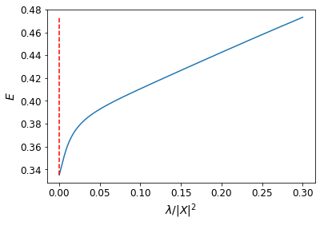

```python
#code for rigde
q = 200
lmax = np.linalg.norm(X_train,2)**2
lambda_list = lmax*np.linspace(.3,1e-6,q)
X = np.zeros( (d,q) )
E = np.zeros( (q,1) )
for i in np.arange(0, q):
    Lambda = lambda_list[i]
    x = np.linalg.solve( X_train.transpose().dot(X_train) + Lambda*np.eye(d), X_train.transpose().dot(y_train) )
    X[:,i] = x.flatten() # bookkeeping
    E[i] = np.linalg.norm(X_train.dot(x)-y_train) / np.linalg.norm(y_train)
# find optimal lambda
i = E.argmin()
lambda0 = lambda_list[i]
xRidge = X[:,i]
print( 'Ridge: ' + str(E.min()*100) + '%' )
# Display error evolution.
plt.clf
plt.plot(lambda_list/lmax, E)
plt.plot( [lambda0/lmax,lambda0/lmax], [E.min(), E.max()], 'r--')
plt.axis('tight')
plt.xlabel('$\lambda/|X|^2$')
plt.ylabel('$E$')
```

# 3 Optional things

- Newton Method
- Multi Perceptron Layers

## 3.1 Quasi-Newton method

Quaisi-Newton use the iterate to update the solution:

$$x_{k+1} = x_{k} + α_{k}*p_{k}$$

base on the method $p_k$ is calculated difference.

1. In newton method $p_{k}= -B_{k}^{-1}∇f(x_k)$ where $B_k=∇^2f(x)$ is the Hessian matrix of $f(x)$, and $α_{k}$ is searched by line search. In the Linear Regession $∇^2f(x)=X^TX$
2. For the Broyden, Fletcher, Goldfarb, and Shanno (BFGS) method, $p_k$ is calculated more complicate:

Given starting point $x_{0}$, convergence tolerance $\epsilon>0$, inverse Hessian approximation $H_0$; each iteration will calculate:

$p_{k}=-H_{k} \nabla f_{k}$

Set $ x_{k+1}=x_{k}+\alpha_{k} p_{k}$ where $ \alpha_{k}$ is computed from a line search procedure to satisfy the Wolfe conditions

Define $s_{k}=x_{k+1}-x_{k}$ and $ y_{k}=\nabla f_{k+1}-\nabla f_{k}$

Compute $H_{k+1}$ by

$$ H_{k+1}=\left(I-\rho_{k} s_{k} y_{k}^{T}\right) H_{k}\left(I-\rho_{k} y_{k} s_{k}^{T}\right)+\rho_{k} s_{k} s_{k}^{T}, $$

where $\rho_{k}=\frac{1}{y_k^T s_k}$

```python
#code for Newton method

def f(w): return 1/2*np.linalg.norm(X_train.dot(w)-y_train)**2
def Gradf(w): return X_train.transpose().dot(X_train.dot(w)-y_train)
def hessian(): return X_train.T.dot(X_train)

def Quasi_Newton(w, Lambda):
    Hess = hessian()
    Inver_Hess = np.linalg.pinv(Hess)
    Grad = Gradf(w)
    pk = Inver_Hess.dot(Grad)
    w = w - Lambda*pk
    return w

w1 = np.zeros((d,1))
all_f = []
for i in range(500):
    w1 = Quasi_Newton(w1, 0.01)
    all_f.append(f(w1))
```

```
fmin = 2305.373929079583
MSE on testing set with Newton Method = 0.11012949620476828
```

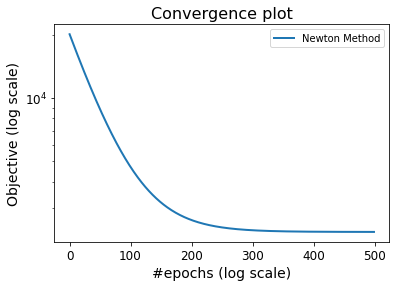

```python
f_min = f(w1)
print("fmin = {}".format(f_min))
print("MSE on testing set with Newton Method = {}".format(mean_squared_error(y_test, X_test.dot(w1))))
plt.semilogy(all_f, label="Newton Method", lw=2)
plt.title("Convergence plot", fontsize=16)
plt.xlabel("#epochs (log scale)", fontsize=14)
plt.ylabel("Objective (log scale)", fontsize=14)
plt.legend()
plt.show()
```

```python
#code for BFGS

def Gradf_BFGS(w): return X_train.transpose().dot(X_train.dot(w)-y_train.reshape(n,1))
def BFGS(Lambda=0.01, iter=100):
    H_k = np.linalg.pinv(hessian())
    x_k = np.zeros((d, 1))
    all_f = []
    for i in range(iter):
        p_k = -H_k.dot(Gradf_BFGS(x_k))
        x_kp1 = x_k + Lambda*p_k
        s_k = x_kp1 - x_k
        y_k = Gradf_BFGS(x_kp1)-Gradf_BFGS(x_k)
        u = 1/y_k.T.dot(s_k)
        temp_1 = u*s_k.dot(y_k.T)
        Id_1 = np.identity(d)
        temp_2 = u*y_k.dot(s_k.T)
        Id_2 = np.identity(d)
        temp_3 = u*s_k.dot(s_k.T)
        H_k = (Id_1 - temp_1).dot(H_k).dot(Id_2 - temp_2) + temp_3
        x_k = x_kp1
        all_f.append(f(x_k))
    return x_k, all_f

w, all_f = BFGS(iter=500)
```

```
MSE on testing set with BFGS method = 0.11011693465089858
fmin = 2305.373929079583
```

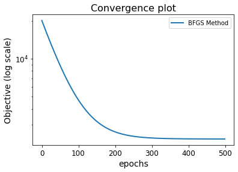

```python
f_min = f(w)
print("MSE on testing set with BFGS method = {}".format(mean_squared_error(y_test, X_test.dot(w_target))))
print("fmin = {}".format(f_min))
plt.semilogy(all_f, label="BFGS Method", lw=2)
plt.title("Convergence plot", fontsize=16)
plt.xlabel("epochs", fontsize=14)
plt.ylabel("Objective (log scale)", fontsize=14)
plt.legend()
plt.show()
```

## 3.2 Multilayer Perceptron¶

[figure not shown]

A multilayer perceptron (MLP) is a class of feedforward artificial neural network (ANN). An MLP consists of at least three layers of nodes: an input layer, a hidden layer and an output layer. Except for the input nodes, each node is a neuron that uses a nonlinear activation function.

MLP will minimize the function $$ \min _{A, c} \mathcal{E}(A, c) \equiv \frac{1}{2} \sum_{i=1}^{n}\left(f_{A, c}\left(x_{i}\right)-y_{i}\right)^{2}=\frac{1}{2}\|\varphi(X A) c-y\|^{2} $$

this function can solve by Gradient Descent on the variable $A$ and $c$, but when tested the function is not convergence.

```python
#code for Multilayer Perceptron

# code for Multi Perceptron
X_new = np.hstack(( X_train, np.ones((n,1)) ))
y_new = y_train.reshape(n,1)

def phi(x): return 1/(1+np.exp(-x))
def phiD(x): return np.exp(-x)/(1+np.exp(-x))**2
def Phi(A,c): return phi(X_new.dot(A)).dot(c)
def PhiD(A,c): return phiD(X_new.dot(A)).dot(c)

def E(A,c): return 1/(2*n)*np.linalg.norm(Phi(A,c)-y_new)**2
def R(A,c): return Phi(A,c)-y_new;
def nablaEc(A,c): return 1/n * ( phi(X_new.dot(A)).transpose() ).dot( R(A,c) )
def nablaEA(A,c): return 1/n * X_new.transpose().dot( phiD(X_new.dot(A)) * ( R(A,c).dot(c.transpose()) ) )

q = 20
A = np.random.randn(d+1,q)*10
c = np.random.randn(q,1)/10
niter = 500
Elist = np.zeros((niter,1))
tauA = 0.01
tauc = 0.01
for it in np.arange(0,niter):
    Elist[it] = E(A,c)
    gA = nablaEA(A,c)
    gc = nablaEc(A,c)
    A = A - tauA*gA
    c = c - tauc*gc
```

```python
diff = E(A,c) - f(w_target)/n
print("difference beetween GD Multi Perceptron and min is: {}".format(diff))
```

```
difference beetween GD Multi Perceptron and min is: 0.08527774436805063
```

=> Multilayer Perceptron with Gradient Descent is not find the solution.

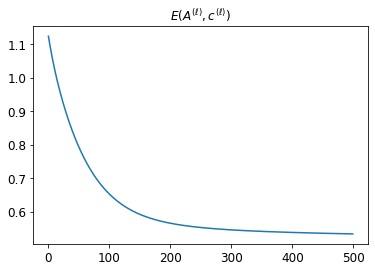

```python
plt.clf
plt.plot(np.sqrt(2*Elist))
plt.title('$E(A^{(\ell)}, c^{(\ell)})$');
```

```python
#BFGS
def MakeCol(y): return y.reshape(-1,1)

def BFGSfunc(u):
    A = u[0:q*(d+1)].reshape((d+1),q)
    c = MakeCol( u[q*(d+1):] )
    return E(A,c); # 1/2*np.linalg.norm(c)**2
def nablaBFGSfunc(u):
    A = u[0:q*(d+1)].reshape((d+1),q)
    c = MakeCol( u[q*(d+1):] )
    gc = nablaEc(A,c).flatten()
    gA = nablaEA(A,c).flatten()
    return np.concatenate((gA, gc), axis=0)

A = np.random.randn(d+1,q)
c = np.random.randn(q,1)
u = np.concatenate((A.flatten(), c.flatten()), axis=0)

from scipy.optimize import minimize
res = minimize(BFGSfunc, u, method='BFGS', jac=nablaBFGSfunc, options={'gtol': 1e-6, 'disp': True, 'maxiter': 600});
u = res.x
A = u[0:q*(d+1)].reshape((d+1),q)
c = MakeCol( u[q*(d+1):] )
```

```python
diff = E(A,c) - f(w_target)/n
print("difference beetween GD Multi Perceptron and min is: {}".format(diff))
```

```
difference beetween GD Multi Perceptron and min is: -0.042282690088719044
```

```python
#test with testing set
X_testnew = np.hstack(( X_test, np.ones((X_test.shape[0],1)) ))
y_testnew = y_test.reshape(X_test.shape[0],1)

y_predict = phi(X_testnew.dot(A)).dot(c)
mse = mean_squared_error(y_testnew, y_predict)
print("Loss on testing set with MLP = {}".format(mse))

print("Loss on testing set with Optimal Solution = {}".format(mean_squared_error(y_test, X_test.dot(w_target))))
```

```
Loss on testing set with MLP = 0.028580443710929413
Loss on testing set with Optimal Solution = 0.11011693465089858
```